# gg_texture_triangle: Full API Reference

```r
library(tidysoiltexture)
library(ggplot2)
library(tibble)
```

This vignette walks through every parameter of `gg_texture_triangle()`, `texture_surface()`, `geom_texture_contour()`, and `texture_label_style()`, with a rendered example for each.

## Sample data

All examples use these two datasets:

```r
# A handful of labelled soil samples
pts <- tibble(
  sand  = c(70, 20, 40, 10, 55, 30),
  silt  = c(15, 30, 40, 20, 30, 45),
  clay  = c(15, 50, 20, 70, 15, 25),
  label = c("A", "B", "C", "D", "E", "F")
)

# A denser grid of points with a synthetic soil property
set.seed(4291)
surf_df <- tibble(
  sand = runif(90, 5, 88),
  clay = runif(90, 5, 55)
) |>
  dplyr::mutate(silt = 100 - sand - clay) |>
  dplyr::filter(silt >= 2) |>
  dplyr::mutate(prop = clay * 0.55 + sand * 0.08 + rnorm(dplyr::n(), 0, 4))
```

## 1. Basic usage

Minimum required arguments are a data frame and three bare column names. Sample points are drawn as black dots by default.

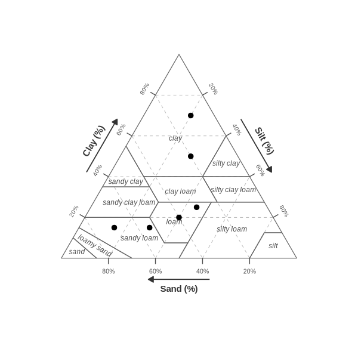

```r
gg_texture_triangle(pts, sand, silt, clay)
```

Map a column to point colour with `colour`:

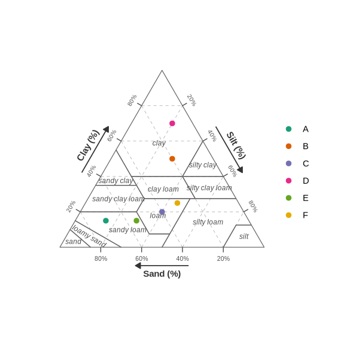

```r
gg_texture_triangle(pts, sand, silt, clay, colour = label) +
  scale_colour_brewer(palette = "Dark2", name = NULL)
```

## 2. Fill style (`style`)

`style = "none"` (default) — unfilled regions, borders only.

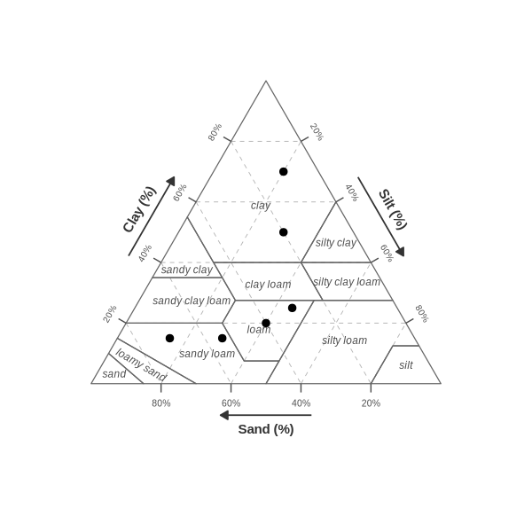

```r
gg_texture_triangle(pts, sand, silt, clay, style = "none")
```

`style = "wiki"` — colour scheme matching the Wikipedia USDA texture diagram.

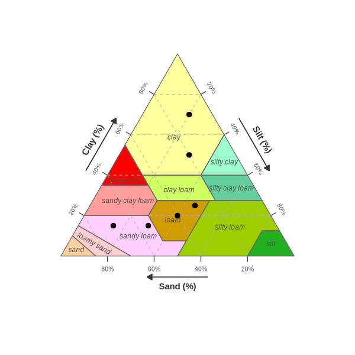

```r
gg_texture_triangle(pts, sand, silt, clay, style = "wiki")
```

## 3. Grid breaks (`breaks`)

Control where grid lines and tick marks are drawn. Pass any numeric vector of percentages between 1 and 99.

**Quarters** — `c(25, 50, 75)`

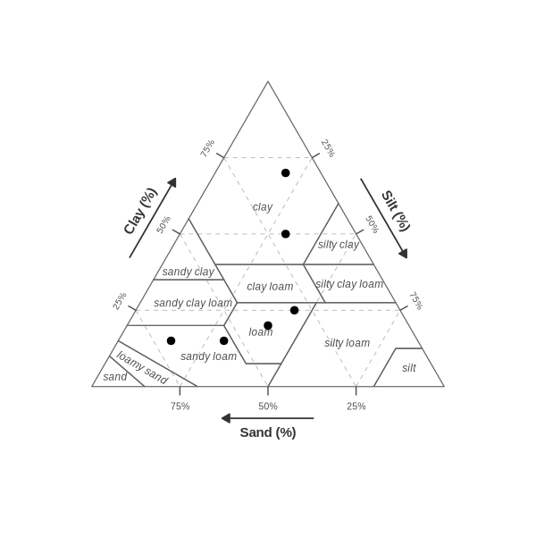

```r
gg_texture_triangle(pts, sand, silt, clay, breaks = c(25, 50, 75))
```

**Every 10 %** — `seq(10, 90, 10)`

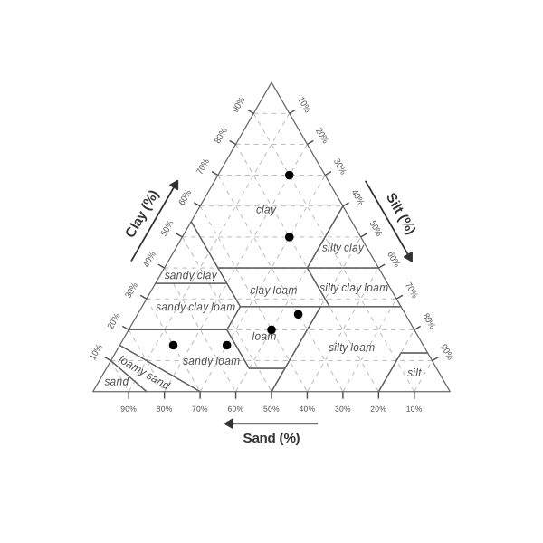

```r
gg_texture_triangle(pts, sand, silt, clay, breaks = seq(10, 90, 10))
```

**Every 5 %** — `seq(5, 95, 5)`. Tick label size auto-scales down.

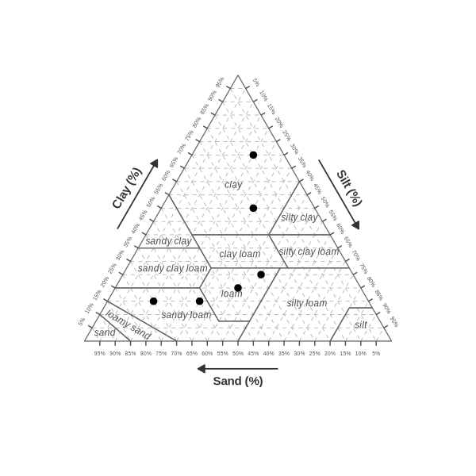

```r
gg_texture_triangle(pts, sand, silt, clay, breaks = seq(5, 95, 5))
```

## 4. Grid line style (`grid_colour`, `grid_linetype`, `grid_linewidth`)

All three parameters control the internal dashed grid lines.

**Darker, thicker, solid:**

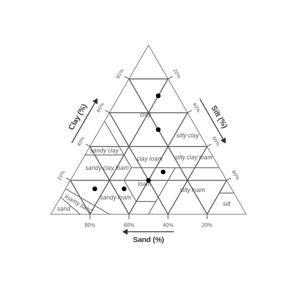

```r
gg_texture_triangle(pts, sand, silt, clay,
  grid_colour    = "grey30",
  grid_linetype  = "solid",
  grid_linewidth = 0.5)
```

**Dotted, light:**

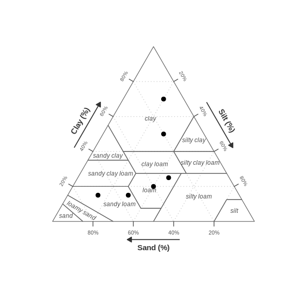

```r
gg_texture_triangle(pts, sand, silt, clay,
  grid_colour    = "grey80",
  grid_linetype  = "dotted",
  grid_linewidth = 0.4)
```

**Hidden** — set `grid_linetype = "blank"`:

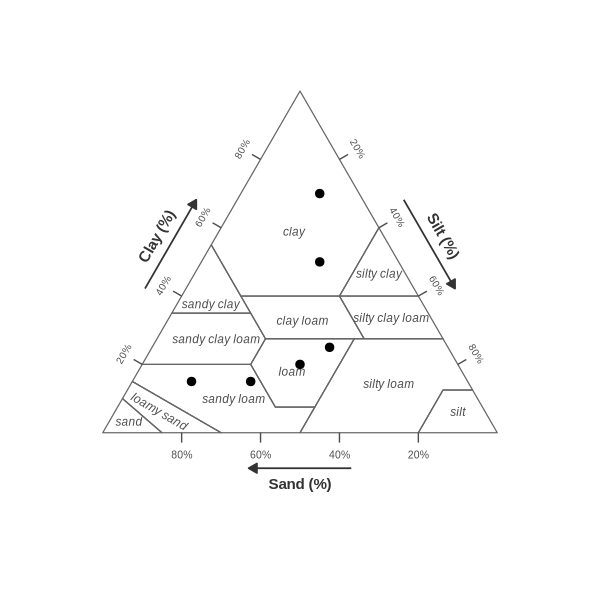

```r
gg_texture_triangle(pts, sand, silt, clay,
  grid_linetype = "blank")
```

## 5. Class border style (`border_colour`, `border_linewidth`)

Control the lines separating texture class regions.

**Bold black borders:**

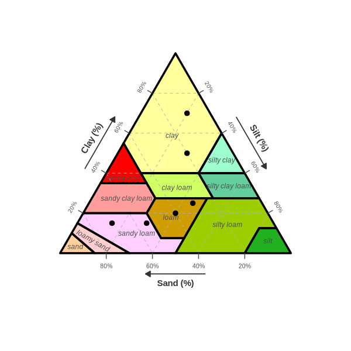

```r
gg_texture_triangle(pts, sand, silt, clay, style = "wiki",
  border_colour    = "black",
  border_linewidth = 1.0)
```

**Hidden borders** — set `border_colour = NA`:

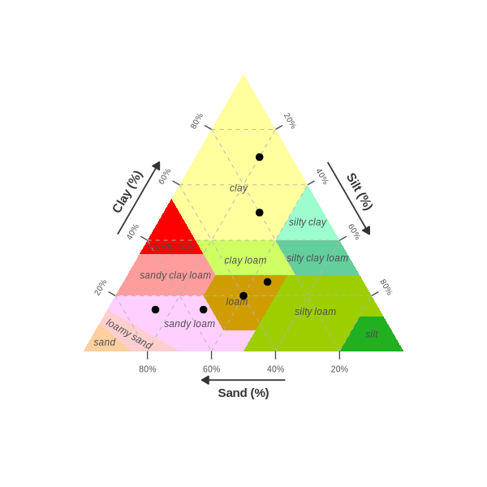

```r
gg_texture_triangle(pts, sand, silt, clay, style = "wiki",
  border_colour = NA)
```

## 6. Tick height (`tick_height`)

`tick_height = NULL` (default) auto-scales with break density. Set to `0` to hide all tick marks while keeping grid lines and labels.

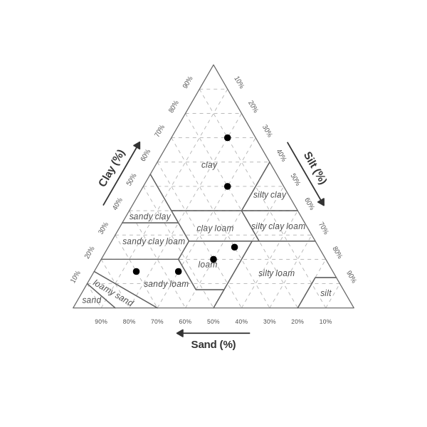

```r
gg_texture_triangle(pts, sand, silt, clay,
  breaks      = seq(10, 90, 10),
  tick_height = 0)
```

Set a fixed height (in Cartesian units) to make ticks longer or shorter:

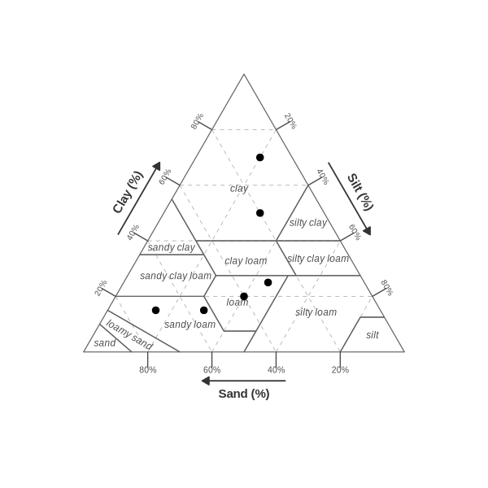

```r
gg_texture_triangle(pts, sand, silt, clay,
  tick_height = 0.05)
```

## 7. Label style (`texture_label_style()`)

`texture_label_style()` returns a validated list for the `label_style` argument. Supply only the keys you want to override.

### 7a. Tick labels (`tick_show`, `tick_size`)

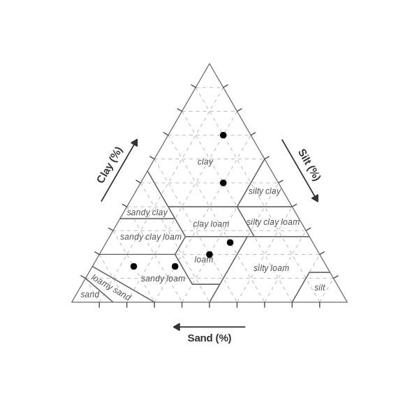

```r
# Hide percentage labels, keep ticks and grid
gg_texture_triangle(pts, sand, silt, clay,
  breaks      = seq(10, 90, 10),
  label_style = texture_label_style(tick_show = FALSE))
```

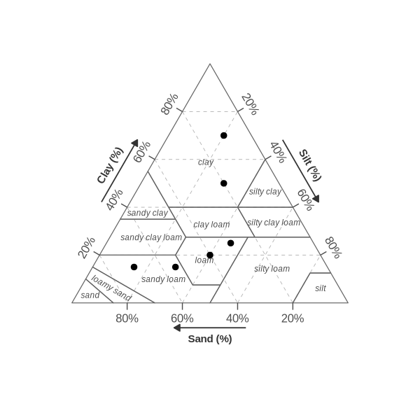

```r
# Larger tick labels
gg_texture_triangle(pts, sand, silt, clay,
  label_style = texture_label_style(tick_size = 3.5))
```

### 7b. Axis name labels (`axis_show`, `axis_size`)

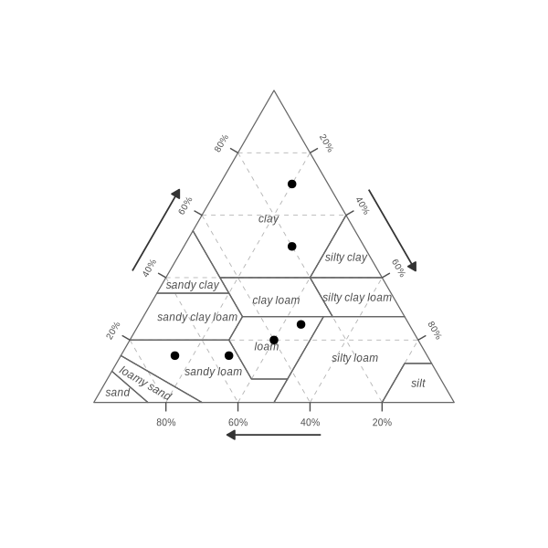

```r
# Bare triangle — no axis names, just arrows
gg_texture_triangle(pts, sand, silt, clay,
  label_style = texture_label_style(axis_show = FALSE))
```

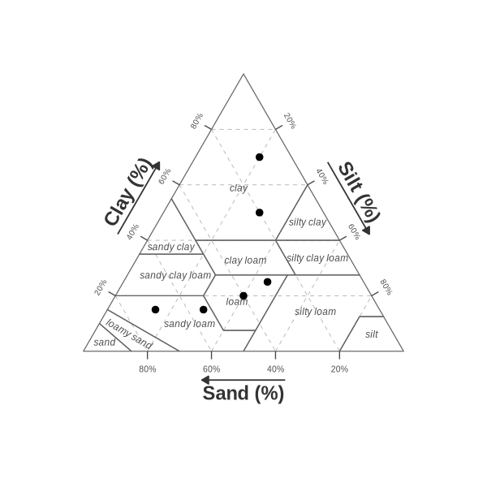

```r
gg_texture_triangle(pts, sand, silt, clay,
  label_style = texture_label_style(axis_size = 5))
```

### 7c. Texture class labels (`class_show`, `class_size`)

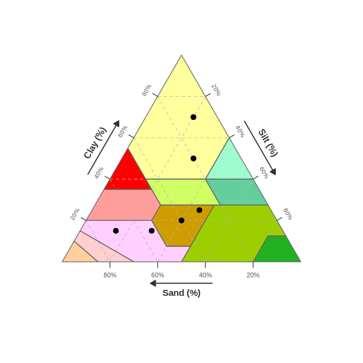

```r
gg_texture_triangle(pts, sand, silt, clay, style = "wiki",
  label_style = texture_label_style(class_show = FALSE))
```

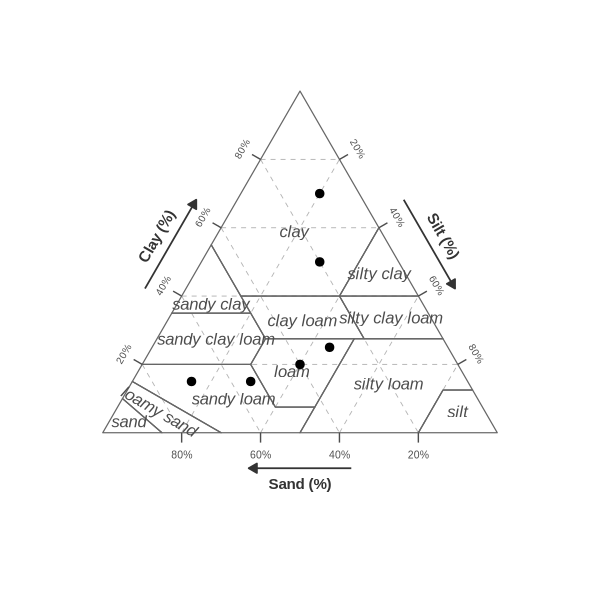

```r
gg_texture_triangle(pts, sand, silt, clay,
  label_style = texture_label_style(class_size = 3.5))
```

### 7d. Suppressing everything

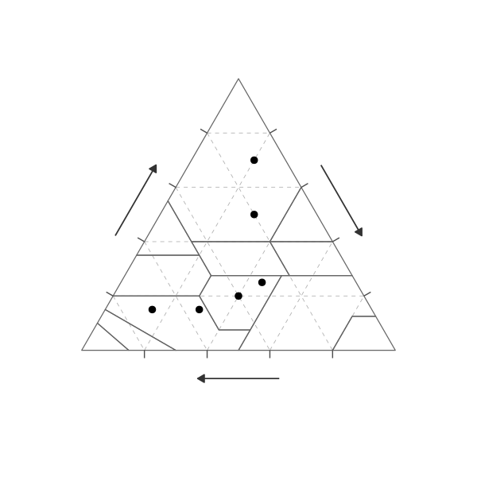

```r
gg_texture_triangle(pts, sand, silt, clay,
  label_style = texture_label_style(
    tick_show  = FALSE,
    axis_show  = FALSE,
    class_show = FALSE))
```

## 8. Continuous surface (`texture_surface()`)

`texture_surface()` constructs an IDW-interpolated surface from scattered ternary sample points. Pass it to the `surface` argument of `gg_texture_triangle()`; the fill scale is left open for any `scale_fill_*()` call.

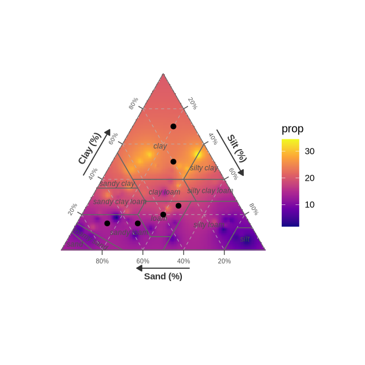

```r
gg_texture_triangle(pts, sand, silt, clay,
  surface = texture_surface(surf_df, sand, silt, clay, z = prop)) +
  scale_fill_viridis_c(name = "prop", option = "plasma")
```

**`resolution`** controls interpolation grid density (default 150). Higher = smoother, slower.

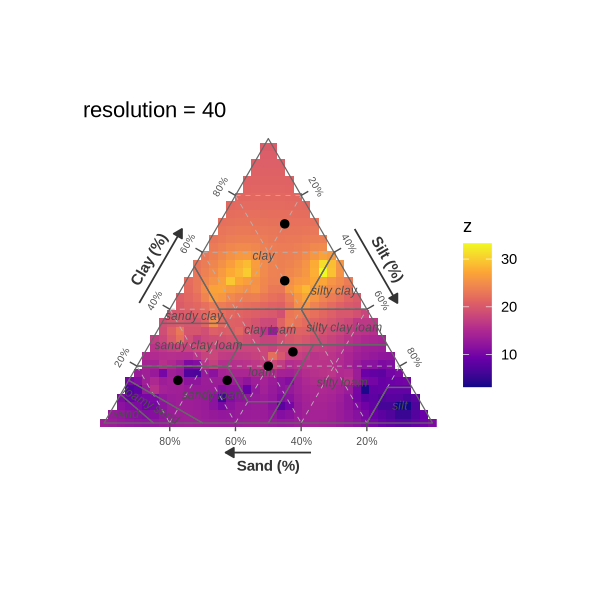

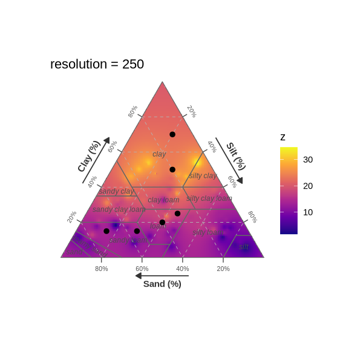

```r
gg_texture_triangle(pts, sand, silt, clay,
  surface = texture_surface(surf_df, sand, silt, clay, z = prop,
                             resolution = 40L)) +
  scale_fill_viridis_c(option = "plasma") +
  ggtitle("resolution = 40")

gg_texture_triangle(pts, sand, silt, clay,
  surface = texture_surface(surf_df, sand, silt, clay, z = prop,
                             resolution = 250L)) +
  scale_fill_viridis_c(option = "plasma") +
  ggtitle("resolution = 250")
```

**`power`** controls IDW locality (default 2). Higher = more local, spikier.

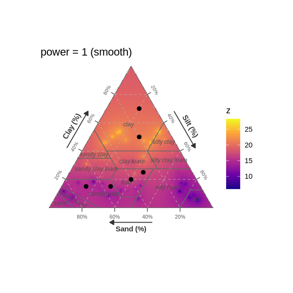

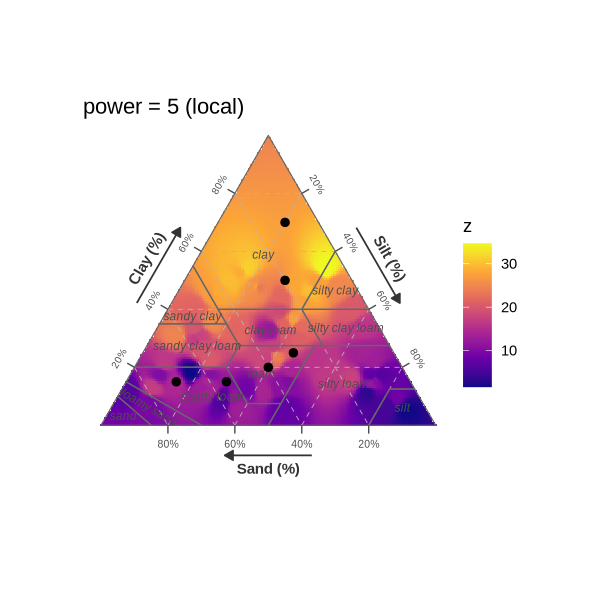

```r
gg_texture_triangle(pts, sand, silt, clay,
  surface = texture_surface(surf_df, sand, silt, clay, z = prop,
                             power = 1)) +
  scale_fill_viridis_c(option = "plasma") +
  ggtitle("power = 1 (smooth)")

gg_texture_triangle(pts, sand, silt, clay,
  surface = texture_surface(surf_df, sand, silt, clay, z = prop,
                             power = 5)) +
  scale_fill_viridis_c(option = "plasma") +
  ggtitle("power = 5 (local)")
```

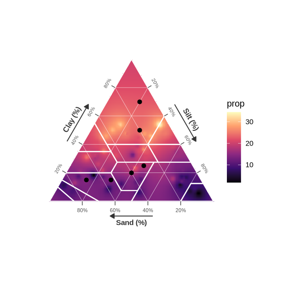

```r
gg_texture_triangle(pts, sand, silt, clay,
  surface          = texture_surface(surf_df, sand, silt, clay, z = prop),
  border_colour    = "white",
  border_linewidth = 0.6,
  grid_colour      = "white",
  grid_linetype    = "solid",
  grid_linewidth   = 0.15,
  label_style      = texture_label_style(class_show = FALSE)) +
  scale_fill_viridis_c(name = "prop", option = "magma")
```

## 9. Contour lines (`geom_texture_contour()`)

`geom_texture_contour()` returns a ggplot2 layer that adds iso-lines at specified `breaks`. It works on any texture triangle, with or without a surface.

### Contours on a plain triangle

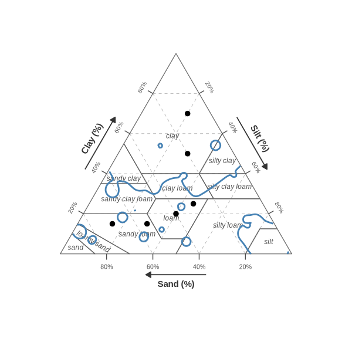

```r
gg_texture_triangle(pts, sand, silt, clay) +
  geom_texture_contour(surf_df, sand, silt, clay, z = prop,
    breaks    = c(10, 20, 30),
    colour    = "steelblue",
    linewidth = 0.8)
```

### Contours on a wiki-coloured triangle

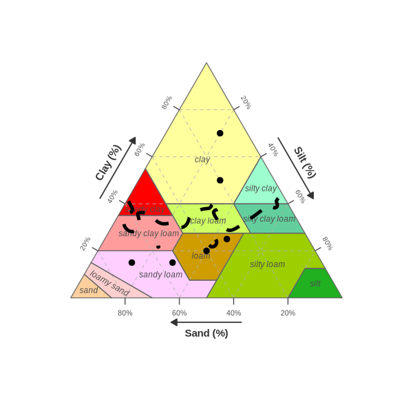

```r
gg_texture_triangle(pts, sand, silt, clay, style = "wiki") +
  geom_texture_contour(surf_df, sand, silt, clay, z = prop,
    breaks    = 20,
    colour    = "black",
    linewidth = 1.4,
    linetype  = "dashed")
```

### Contours on a surface — threshold annotation

A single bold contour highlighting a threshold (e.g. where `prop = 20`):

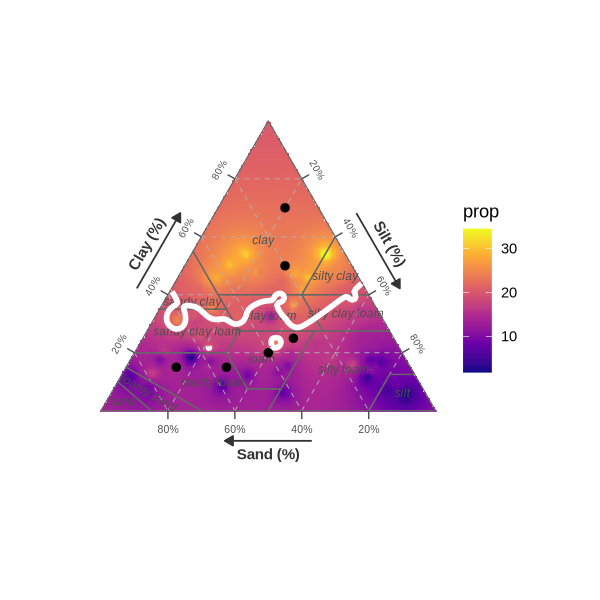

```r
gg_texture_triangle(pts, sand, silt, clay,
  surface = texture_surface(surf_df, sand, silt, clay, z = prop)) +
  scale_fill_viridis_c(name = "prop", option = "plasma") +
  geom_texture_contour(surf_df, sand, silt, clay, z = prop,
    breaks    = 20,
    colour    = "white",
    linewidth = 1.6)
```

## 10. Combining parameters

A publication-ready black-and-white triangle with 10 % grid, no tick labels, bold borders, and labelled sample points:

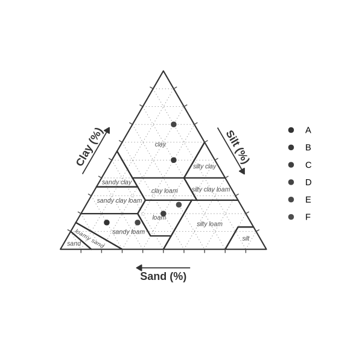

```r
gg_texture_triangle(pts, sand, silt, clay,
  colour           = label,
  breaks           = seq(10, 90, 10),
  grid_colour      = "grey50",
  grid_linetype    = "dotted",
  border_colour    = "grey20",
  border_linewidth = 0.6,
  tick_height      = 0.018,
  label_style      = texture_label_style(
    tick_show  = FALSE,
    axis_size  = 3.8,
    class_size = 2.2)) +
  scale_colour_grey(name = NULL, end = 0.3)
```

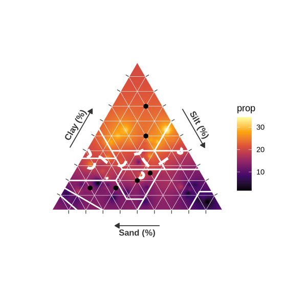

```r
gg_texture_triangle(pts, sand, silt, clay,
  surface          = texture_surface(surf_df, sand, silt, clay,
                                     z = prop, resolution = 200L),
  breaks           = seq(10, 90, 10),
  grid_colour      = "white",
  grid_linetype    = "solid",
  grid_linewidth   = 0.2,
  border_colour    = "white",
  border_linewidth = 0.7,
  label_style      = texture_label_style(
    class_show = FALSE,
    tick_show  = FALSE,
    axis_size  = 3.5)) +
  scale_fill_viridis_c(name = "prop", option = "inferno") +
  geom_texture_contour(surf_df, sand, silt, clay, z = prop,
    breaks = 20, colour = "white", linewidth = 1.5, linetype = "dashed")
```